# Assignment for R - Part 2 : Exploration, Management, Visualization and Regression

Rita U. Kayitana

2026-10-31

# Loading the Data Used in This Document

This Part use data from three sources imported in Part 1: the Stata file, the MySQL `employee` table and the Access `students` table.

```r
# Stata file (air quality data, contains missing values in Ozone)
stata_data <- read_dta(file.path(data_dir, "session saved in stata.dta"))

# MySQL: employee table
con_mysql <- dbConnect(RMariaDB::MariaDB(),
                       host = "localhost",
                       dbname = "wpdbase",
                       user = "root")      # add password = "..." if you have one
employees <- dbReadTable(con_mysql, "employee")
dbDisconnect(con_mysql)

# Microsoft Access: students table
con_access <- dbConnect(
  odbc::odbc(),
  .connection_string = paste0(
    "Driver={Microsoft Access Driver (*.mdb, *.accdb)};",
    "Dbq=C:/Users/USER/OneDrive/Documents/database to export to R.accdb;"
  )
)
students <- dbReadTable(con_access, "students")
dbDisconnect(con_access)

data("iris")
```

# Part 2: Exploring and Analysing Datasets

This part calculates descriptive statistics, examines distributions, checks data types and runs cross-tabulations to detect underlying trends or anomalies.

## 1. General Summaries and Inspection

Using the `students` dataset imported from the Access database:

```r
str(students)              # structure and data types (6 observations, 7 variables)
```

```
## 'data.frame':    6 obs. of  7 variables:
##  $ StudentID   : chr  "01" "02" "03" "04" ...
##  $ StudentNames: chr  "amina" "john" "grace" "david" ...
##  $ studentage  : int  20 22 21 23 20 19
##  $ course      : chr  "biology" "chemistry" "biology" "physics" ...
##  $ score       : int  78 85 91 67 88 50
##  $ Height      : int  161 155 158 170 160 156
##  $ Weight      : int  50 49 42 65 60 52
```

```r
names(students)            # variable names
```

```
## [1] "StudentID"    "StudentNames" "studentage"   "course"       "score"
## [6] "Height"       "Weight"
```

```r
students$StudentNames      # only the student names column
```

```
## [1] "amina" "john"  "grace" "david" "sarah" "paul"
```

```r
students[3:6, ]            # rows 3 to 6, all columns
```

```
##   StudentID StudentNames studentage    course score Height Weight
## 3        03        grace         21   biology    91    158     42
## 4        04        david         23   physics    67    170     65
## 5        05        sarah         20 chemistry    88    160     60
## 6        06         paul         19   physics    50    156     52
```

```r
students[4:6, -c(3, 5, 6)] # rows 4 to 6, dropping columns 3, 5 and 6
```

```
##   StudentID StudentNames    course Weight
## 4        04        david   physics     65
## 5        05        sarah chemistry     60
## 6        06         paul   physics     52
```

Descriptive statistics, and applying an operation across columns

```r
summary(students)                                   # min, quartiles, median, mean, max
```

```
##   StudentID         StudentNames         studentage       course
##  Length:6           Length:6           Min.   :19.00   Length:6
##  Class :character   Class :character   1st Qu.:20.00   Class :character
##  Mode  :character   Mode  :character   Median :20.50   Mode  :character
##                                        Mean   :20.83
##                                        3rd Qu.:21.75
##                                        Max.   :23.00
##      score           Height          Weight
##  Min.   :50.00   Min.   :155.0   Min.   :42.00
##  1st Qu.:69.75   1st Qu.:156.5   1st Qu.:49.25
##  Median :81.50   Median :159.0   Median :51.00
##  Mean   :76.50   Mean   :160.0   Mean   :53.00
##  3rd Qu.:87.25   3rd Qu.:160.8   3rd Qu.:58.00
##  Max.   :91.00   Max.   :170.0   Max.   :65.00
```

```r
sd(students$studentage)                             # standard deviation of student age
```

```
## [1] 1.47196
```

```r
apply(students[, c("Weight", "Height")], 2, mean)   # column-wise means
```

```
## Weight Height
##     53    160
```

Mean and standard deviation for a specific species in the `iris` dataset:

```r
mean(iris$Petal.Length[iris$Species == "virginica"])
```

```
## [1] 5.552
```

```r
sd(iris$Sepal.Length[iris$Species == "setosa"])
```

```
## [1] 0.3524897
```

## 2. Cross-Tabulation

The built-in `UCBAdmissions` dataset shows female and male admission decisions at a university.

```r
ucba <- data.frame(UCBAdmissions)

# Contingency table: admission decision by gender, with frequencies
(cross <- xtabs(Freq ~ Gender + Admit, data = ucba))
```

```
##         Admit
## Gender   Admitted Rejected
##   Male       1198     1493
##   Female      557     1278
```

```r
# Row proportions: admission and rejection rates by gender
prop.table(cross, 1)
```

```
##         Admit
## Gender    Admitted  Rejected
##   Male   0.4451877 0.5548123
##   Female 0.3035422 0.6964578
```

# Part 3: Data Management and Transformation

Data management is everything you do to organise, clean and prepare data so it is accurate, consistent and ready to analyse. Examples include sorting, filtering, handling missing values and creating new variables.

## 1. Sorting, Selecting and Filtering

This section uses the `employees` data imported from MySQL.

Sorting rows by last name in alphabetical order:

```r
sorted_employees <- employees[order(employees$LastName), ]
head(sorted_employees)
```

```
##    EmployeeNumber FirstName LastName Department        Position Supervisor
## 5               5       Tom    Baker      Sales   Sales Manager         NA
## 6               6      Nina   Brooks         IT       Developer          3
## 7               7      Carl     Diaz         IT       Developer          3
## 8               8      Ella     Ford      Sales       Sales Rep          5
## 9               9     Derek     Gray    Finance         Analyst          2
## 11             11      Owen   Hughes Operations Ops Coordinator          1
##    OfficePhone            EmailAddress
## 5     555-2004   tom.baker@company.com
## 6     555-2005 nina.brooks@company.com
## 7     555-2006   carl.diaz@company.com
## 8     555-2007   ella.ford@company.com
## 9     555-2008  derek.gray@company.com
## 11    555-2010 owen.hughes@company.com
```

Selecting specific columns: each employee with their supervisor.

```r
names(employees)
```

```
## [1] "EmployeeNumber" "FirstName"      "LastName"       "Department"
## [5] "Position"       "Supervisor"     "OfficePhone"    "EmailAddress"
```

```r
selected_vars <- c("FirstName", "Supervisor")
(employee_supervisor <- employees[selected_vars])
```

```
##    FirstName Supervisor
## 1       John         NA
## 2       Mary         NA
## 3       Alan         NA
## 4       Sara         NA
## 5        Tom         NA
## 6       Nina          3
## 7       Carl          3
## 8       Ella          5
## 9      Derek          2
## 10     PRIYA          1
## 11      Owen          1
## 12      Lena          4
## 13     Marco          3
## 14     Julia          3
## 15     Peter          3
```

Filtering rows: employees and their departments where the supervisor number is 3.

```r
employees
```

```
##    EmployeeNumber FirstName LastName        Department          Position
## 1               1      John    Smith   Human Resources       HR Director
## 2               2      Mary    Jones        Accounting        Controller
## 3               3      Alan   Turner                IT        IT Manager
## 4               4      Sara      Lee         Marketing    Marketing Lead
## 5               5       Tom    Baker             Sales     Sales Manager
## 6               6      Nina   Brooks                IT         Developer
## 7               7      Carl     Diaz                IT         Developer
## 8               8      Ella     Ford             Sales         Sales Rep
## 9               9     Derek     Gray           Finance           Analyst
## 10             10     PRIYA     Shah             Legal           Counsel
## 11             11      Owen   Hughes        Operations   Ops Coordinator
## 12             12      Lena    Ivers  Customer Support      Support Lead
## 13             13     Marco     Ruiz          Research        Researcher
## 14             14     Julia     Kwan       Development Software Engineer
```

[output cut: 17 more lines]

```r
supervisor3 <- subset(employees, Supervisor == 3,
                      select = c(LastName, Department))
supervisor3
```

```
##    LastName        Department
## 6    Brooks                IT
## 7      Diaz                IT
## 13     Ruiz          Research
## 14     Kwan       Development
## 15    Nolan Quality Assurance
```

## 2. Handling Missing Values

You may choose to delete observations with missing values or replace them with the average. The `stata_data` imported from Stata has missing (`NA`) values in the `Ozone` variable. Here they are replaced with the column mean.

```r
cleaned_stata_data <- stata_data                             # copy of the original
ozone_mean <- mean(stata_data$Ozone, na.rm = TRUE)           # mean ignoring NAs
cleaned_stata_data$Ozone[is.na(stata_data$Ozone)] <- ozone_mean

sum(is.na(stata_data$Ozone))          # NA values in the original data
```

```
## [1] 37
```

```r
sum(is.na(cleaned_stata_data$Ozone))  # NA values remaining after cleaning
```

```
## [1] 0
```

```r
head(cleaned_stata_data)              # first rows of the cleaned data
```

```
## # A tibble: 6 × 5
##   Ozone  Wind Month       Day day_cat
##   <dbl> <dbl> <dbl+lbl> <dbl> <dbl+lbl>
## 1  41     7.4 1 [may]       1 1 [Begin]
## 2  36     8   1 [may]       2 1 [Begin]
## 3  12    12.6 1 [may]       3 1 [Begin]
## 4  18    11.5 1 [may]       4 1 [Begin]
## 5  42.1  14.3 1 [may]       5 1 [Begin]
## 6  28    14.9 1 [may]       6 1 [Begin]
```

## 3. Creating Categories

Using `iris`, sepal length is grouped into Small (below 5.5), Medium (5.5 to below 6.5) and Large (6.5 and above).

```r
iris_cat <- iris
iris_cat$SepalCat[iris_cat$Sepal.Length < 5.5] <- "Small"
iris_cat$SepalCat[iris_cat$Sepal.Length >= 5.5 & iris_cat$Sepal.Length < 6.5] <- "Medium"
iris_cat$SepalCat[iris_cat$Sepal.Length >= 6.5] <- "Large"

head(iris_cat)
```

```
##   Sepal.Length Sepal.Width Petal.Length Petal.Width Species SepalCat
## 1          5.1         3.5          1.4         0.2  setosa    Small
## 2          4.9         3.0          1.4         0.2  setosa    Small
## 3          4.7         3.2          1.3         0.2  setosa    Small
## 4          4.6         3.1          1.5         0.2  setosa    Small
## 5          5.0         3.6          1.4         0.2  setosa    Small
## 6          5.4         3.9          1.7         0.4  setosa    Small
```

```r
table(iris_cat$SepalCat)       # frequency of each category
```

```
##
##  Large Medium  Small
##     35     63     52
```

## 4. Creating a New Variable (BMI)

BMI = weight / height squared. This assumes Weight is in kg and Height is in cm (so height is divided by 100 to convert to metres). It uses the `students` dataset.

```r
BMI <- round(students$Weight / (students$Height / 100)^2, digits = 2)
students_bmi <- cbind(students, BMI)    # combine with the original data frame
head(students_bmi)
```

```
##   StudentID StudentNames studentage    course score Height Weight   BMI
## 1        01        amina         20   biology    78    161     50 19.29
## 2        02         john         22 chemistry    85    155     49 20.40
## 3        03        grace         21   biology    91    158     42 16.82
## 4        04        david         23   physics    67    170     65 22.49
## 5        05        sarah         20 chemistry    88    160     60 23.44
## 6        06         paul         19   physics    50    156     52 21.37
```

# Part 4: Data Visualization

Plots reveal distributions and relationships. Linear models quantify those relationships.

## Box-and-Whisker Plot (categorical vs. quantitative variable)

The boxplot compares sepal length across the three iris species. Setosa has the shortest sepals, versicolor is in the middle, and virginica has the longest.

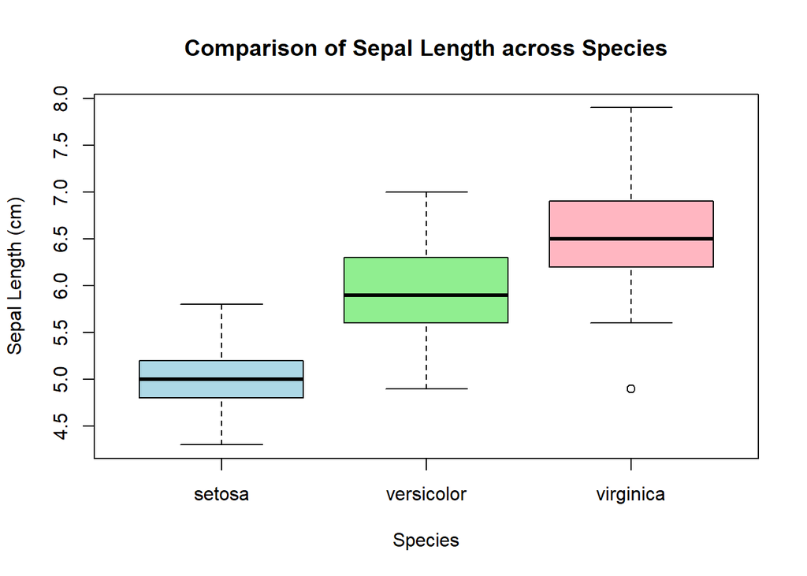

```r
boxplot(Sepal.Length ~ Species, data = iris,
        main = "Comparison of Sepal Length across Species",
        xlab = "Species", ylab = "Sepal Length (cm)",
        col = c("lightblue", "lightgreen", "lightpink"))
```

## Bar Plot (distribution)

The bar chart shows how many employees work in each department, so you can see how staff are distributed across the organisation. It uses the `employees` table.

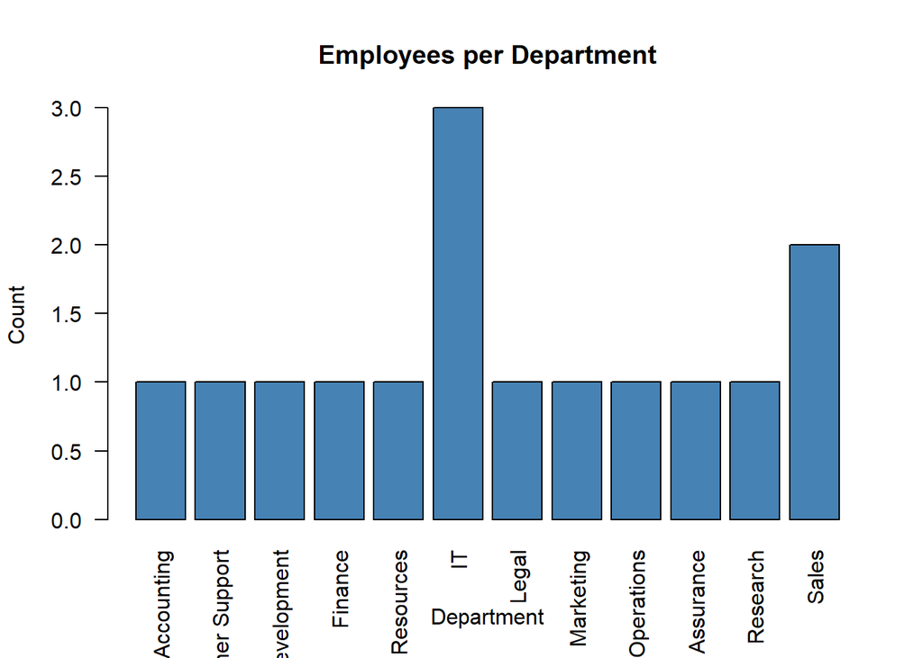

```r
barplot(table(employees$Department),
        main = "Employees per Department",
        xlab = "Department", ylab = "Count",
        col = "steelblue", las = 2)
```

## Scatter Plot: Students’ Height vs. Weight

The plot shows whether taller students also tend to weigh more. Dots rising from left to right mean a positive relationship; no clear direction means a weak or no relationship.

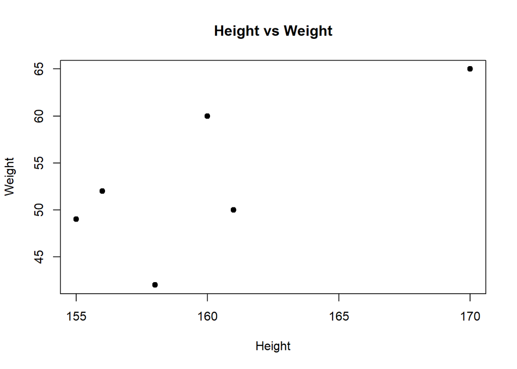

```r
plot(students$Height, students$Weight,
     main = "Height vs Weight",
     xlab = "Height", ylab = "Weight", pch = 19)
```

## Scatter Plot with Linear Regression Line and Lowess Curve

The red line is the linear regression fit and the blue line is the lowess smoothed curve. If the two lines are close, the relationship is roughly linear. If the blue curve bends away from the red line, it is not.

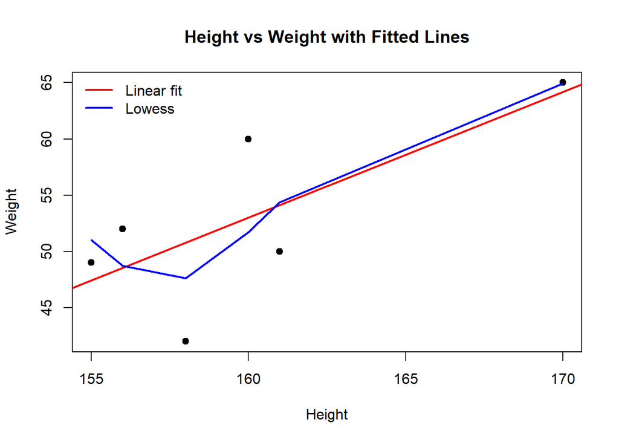

```r
plot(Weight ~ Height, data = students,
     main = "Height vs Weight with Fitted Lines", pch = 19)
abline(lm(Weight ~ Height, data = students), col = "red", lwd = 2)
lines(lowess(students$Height, students$Weight), col = "blue", lwd = 2)
legend("topleft", legend = c("Linear fit", "Lowess"),
       col = c("red", "blue"), lwd = 2, bty = "n")
```

# Part 5: Fitting a Linear Regression Model and Correlation Coefficient

```r
students_lm <- lm(Weight ~ Height, data = students)
summary(students_lm)
```

```
##
## Call:
## lm(formula = Weight ~ Height, data = students)
##
## Residuals:
##       1       2       3       4       5       6
## -4.1164  1.5822 -8.7671  0.8356  7.0000  3.4658
##
## Coefficients:
##              Estimate Std. Error t value Pr(>|t|)
## (Intercept) -125.6301    83.2677  -1.509   0.2059
## Height         1.1164     0.5202   2.146   0.0984 .
## ---
## Signif. codes:  0 '***' 0.001 '**' 0.01 '*' 0.05 '.' 0.1 ' ' 1
##
## Residual standard error: 6.285 on 4 degrees of freedom
## Multiple R-squared:  0.5352, Adjusted R-squared:  0.419
## F-statistic: 4.606 on 1 and 4 DF,  p-value: 0.09839
```

## Correlation coefficient

```r
cor(students$Height, students$Weight)
```

```
## [1] 0.7315967
```

## Interpretation

The model predicts weight from height.

- **Intercept** (-125.63): the predicted weight when height is zero.
- **Height coefficient** (1.116): weight changes by about 1.12 units for each one-unit increase in height.
- **Correlation** (0.732): the correlation ranges from -1 to +1. A value this close to +1 indicates a strong positive relationship, while a value near 0 would indicate a weak one.

# Conclusion

This assignment showed how R can:

- Import data from statistical software, databases, web APIs and built-in datasets.
- Explore it with summaries, descriptive statistics and cross-tabulations.
- Clean and transform it by sorting, filtering, handling missing values and creating new variables.
- Visualize it with box plots, bar plots and scatter plots, and model relationships with linear regression.

Together, these steps form the basic workflow for any data analysis project.